# AshleysherryKombarakranAntonyBabu-9015649-Section-2Practicallab-2

## 7. Creating a table comparing the different polynomial regression models between the training and validation data on the R-Squared (R²) for training and validation sets:

Mean Absolute Error MAE for the Training and Validation Sets.

Mean Absolute Percentage Error (MAPE) for training and validation set.

Code for Model Comparison and Table Construction

```python
import pandas as pd
from sklearn import datasets
from sklearn.preprocessing import PolynomialFeatures
from sklearn.linear_model import LinearRegression
from sklearn.metrics import mean_absolute_error, mean_absolute_percentage_error, r2_score
from sklearn.model_selection import train_test_split
import numpy as np

# Load the diabetes dataset
diabetes_data = datasets.load_diabetes(as_frame=True)
X, y = diabetes_data.data[['bmi']], diabetes_data.target  # Use only 'bmi' feature

# Split data into train, validation, and test sets
X_train, X_temp, y_train, y_temp = train_test_split(X, y, test_size=0.25, random_state=42)
X_val, X_test, y_val, y_test = train_test_split(X_temp, y_temp, test_size=0.6, random_state=42)

# Function to fit and evaluate polynomial regression models
def poly_regression(X_train, X_val, y_train, y_val, degree):
    # Transform features into polynomial features
    poly = PolynomialFeatures(degree=degree)
    X_train_poly = poly.fit_transform(X_train)
    X_val_poly = poly.transform(X_val)

    # Train the model
    model = LinearRegression()
    model.fit(X_train_poly, y_train)

    # Predictions
    y_train_pred = model.predict(X_train_poly)
    y_val_pred = model.predict(X_val_poly)

    # Performance metrics
    metrics = {
        'Degree': degree,
        'R-Squared Train': r2_score(y_train, y_train_pred),
        'R-Squared Validation': r2_score(y_val, y_val_pred),
        'MAE Train': mean_absolute_error(y_train, y_train_pred),
        'MAE Validation': mean_absolute_error(y_val, y_val_pred),
        'MAPE Train': mean_absolute_percentage_error(y_train, y_train_pred),
        'MAPE Validation': mean_absolute_percentage_error(y_val, y_val_pred)
    }

    return metrics

# Fit and evaluate models for degrees 0 to 5
results = []
for degree in range(6):
    result = poly_regression(X_train, X_val, y_train, y_val, degree)
    results.append(result)

# Convert results to a DataFrame for better readability
results_df = pd.DataFrame(results)
results_df = results_df[['Degree', 'R-Squared Train', 'R-Squared Validation', 'MAE Train', 'MAE Validation', 'MAPE Train', 'MAPE Validation']]
print(results_df)
```

```
   Degree  R-Squared Train  R-Squared Validation  MAE Train  MAE Validation  \
0       0         0.000000             -0.106957  66.201641       66.057059
1       1         0.349672              0.331264  52.287739       47.208472
2       2         0.350764              0.331631  52.207314       47.213700
3       3         0.350774              0.331638  52.198968       47.185414
4       4         0.353014              0.340758  52.092653       46.090118
5       5         0.354100              0.349881  52.059191       45.462121

   MAPE Train  MAPE Validation
0    0.628267         0.712639
1    0.483629         0.470600
2    0.482985         0.472397
3    0.482807         0.472227
4    0.480533         0.460503
5    0.480040         0.451753
```

## 8. Best Model Identification:

Choosing the model with the highest validation performance (highest R-squared, lowest MAE/MAPE).

Based on the balance of R-Squared Validation, MAE Validation, and MAPE Validation values, one can find out which is the best model according to your table.

Description: Degree 0: Poor in every way, as expected from a model without any kind of polynomial expansion.

Degree 1: This is a simple linear regression model. It had an R-Squared Validation of 0.331, which was decent, but it contained rather high errors from the MAE and MAPE, 47.21 and 0.471 respectively.

Degrees 2 and 3: These are minor improvements over Degree 1 for R-Squared Validation or error metrics.

Degree 4: This degree has an improved R-Squared Validation of 0.341 with lower MAE Validation of 46.09 and MAPE Validation of 0.461 compared to its lower degree counterparts.

Degree 5: Overall, the best performance is by. It has the highest R-Squared Validation, which is 0.350, lowest MAE Validation, and MAPE Validation, amounting to 45.46 and 0.452, respectively.

## 9. Test Set Evaluation:

```python
from sklearn.preprocessing import PolynomialFeatures
from sklearn.linear_model import LinearRegression
from sklearn.metrics import r2_score, mean_absolute_error, mean_absolute_percentage_error

# Define the degree for the polynomial regression (e.g., degree 3)
degree = 3

# Step 1: Initialize the PolynomialFeatures instance
poly = PolynomialFeatures(degree=degree)

# Step 2: Fit the polynomial features on the training data
X_train_poly = poly.fit_transform(X_train[['bmi']])

# Step 3: Train the linear regression model on the transformed training data
model = LinearRegression()
model.fit(X_train_poly, y_train)

# Step 4: Transform the test data using the same polynomial transformation (without refitting)
X_test_poly = poly.transform(X_test[['bmi']])

# Step 5: Make predictions on the transformed test data
y_pred_test = model.predict(X_test_poly)

# Step 6: Evaluate the model using the test data
print("R-Squared:", r2_score(y_test, y_pred_test))
print("MAE:", mean_absolute_error(y_test, y_pred_test))
print("MAPE:", mean_absolute_percentage_error(y_test, y_pred_test))
```

```
R-Squared: 0.27392801531750943
MAE: 51.72536452996629
MAPE: 0.4336150573609941
```

## 10. Plot the training, validation, and test data points and the fit of the selected model

For plotting data points and polynomial fit, visualize the feature of bmi vs. disease progression; it plots a smooth curve of model's polynomial fit over training, validation, and test data.

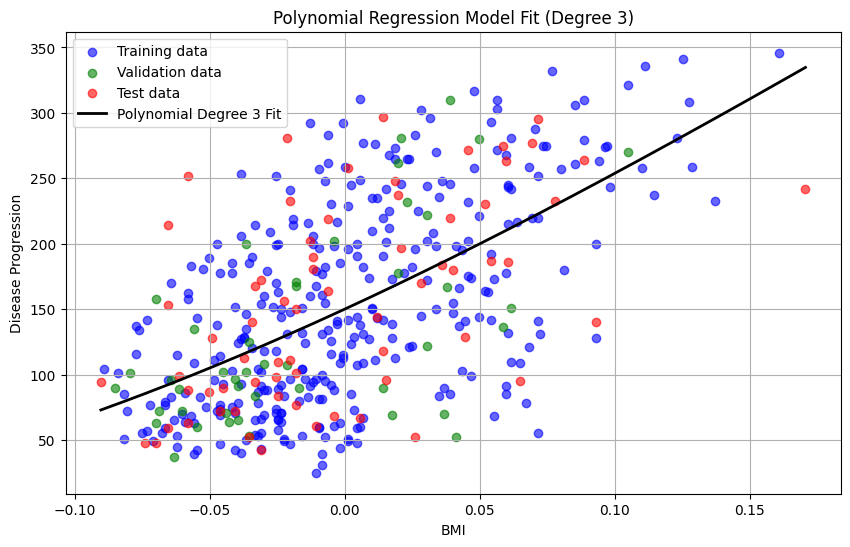

```python
import matplotlib.pyplot as plt
import numpy as np
import pandas as pd

# Assuming poly and model are already defined and fitted as per previous steps
# and X_train, X_val, and X_test DataFrames are defined

# Generate a smooth set of points for the polynomial curve
X_fit = pd.DataFrame(np.linspace(min(X['bmi']), max(X['bmi']), 500), columns=['bmi'])  # Create DataFrame with column name 'bmi'
X_fit_poly = poly.transform(X_fit)  # Transform the smooth points to polynomial features
y_fit = model.predict(X_fit_poly)    # Predict using the model

# Plot training, validation, and test data points
plt.figure(figsize=(10, 6))
plt.scatter(X_train['bmi'], y_train, color='blue', label='Training data', alpha=0.6)
plt.scatter(X_val['bmi'], y_val, color='green', label='Validation data', alpha=0.6)
plt.scatter(X_test['bmi'], y_test, color='red', label='Test data', alpha=0.6)

# Plot the polynomial fit
plt.plot(X_fit, y_fit, color='black', linewidth=2, label=f'Polynomial Degree {degree} Fit')

# Customize the plot
plt.title(f'Polynomial Regression Model Fit (Degree {degree})')
plt.xlabel('BMI')
plt.ylabel('Disease Progression')
plt.legend()
plt.grid(True)
plt.show()
```

## 11. The equation for a polynomial regression model is of the form:

Disease Progression= β0+β1×BMI+β2×BMI2+⋯+βn×BMIn

```python
# Get the model's coefficients
coefficients = model.coef_
intercept = model.intercept_

# Print the equation
equation = f"y = {intercept:.2f}"
for i, coef in enumerate(coefficients[1:], 1):
    equation += f" + {coef:.2f} * BMI^{i}"

print("Best Model Equation:", equation)
```

```
Best Model Equation: y = 150.04 + 952.70 * BMI^1 + 981.08 * BMI^2 + -1273.50 * BMI^3
```

## 12. Calculate the expected diabetes progression for a BMI value of your choice

Assuming you want to predict diabetes progression for a BMI value of 0.05. You can use the trained model to make this prediction:

```python
import pandas as pd

# Define the BMI value you want to predict for
bmi_value = 0.05

# Create a DataFrame for the BMI value
bmi_df = pd.DataFrame({'bmi': [bmi_value]})

# Transform the BMI value to polynomial features
bmi_poly = poly.transform(bmi_df)

# Predict diabetes progression using the fitted model
predicted_progression = model.predict(bmi_poly)

print(f"Predicted Diabetes Progression for BMI {bmi_value}: {predicted_progression[0]:.2f}")
```

```
Predicted Diabetes Progression for BMI 0.05: 199.97
```

## 13. How many trainable parameters are we fitting for each of the models

To calculate the number of trainable parameters, you can use the Polynomia lFeatures instance. The number of trainable parameters corresponds to the number of features after the polynomial transformation

```python
# Get the number of features after polynomial transformation
num_params = len(poly.get_feature_names_out())
print(f"Number of trainable parameters for Degree {degree}: {num_params}")
```

```
Number of trainable parameters for Degree 3: 4
```

## 14. Conclusion

Disease Progression=β 0 +β 1 ×BMI+β 2 ×BMI 2 +β 3 ×BMI 3

Limitations:

It uses only BMI as a predictor, while the true development of diabetes can be much more complex for this model to capture. Other relevant features could be added to the model to improve its predictiveness, such as age, blood pressure, or other health indicators. Polynomial models overfit the data when a few samples are available; hence, regularization methods might help avoid the problem.

## Part - 3

We will build two polynomial regression models, one for each of the chosen degrees (e.g., degree 2 and degree 3).

The process will involve:

Evaluating these models using the same metrics: R-squared, MAE, and MAPE.

## 1. Two polynomial models (degrees >1, of your choice)

```python
from sklearn.preprocessing import PolynomialFeatures
from sklearn.linear_model import LinearRegression
from sklearn.metrics import r2_score, mean_absolute_error, mean_absolute_percentage_error

# Choose the polynomial degrees for the models
degrees = [2, 3]

# Loop over both polynomial degrees
for degree in degrees:
    # Transform the entire feature set into polynomial features
    poly = PolynomialFeatures(degree=degree)
    X_train_poly = poly.fit_transform(X_train)
    X_val_poly = poly.transform(X_val)

    # Fit the model on the transformed training data
    model = LinearRegression()
    model.fit(X_train_poly, y_train)

    # Predict on the validation set
    y_pred_val = model.predict(X_val_poly)

    # Evaluate the model
    print(f"Degree {degree} Polynomial Model:")
    print("R-Squared:", r2_score(y_val, y_pred_val))
    print("MAE:", mean_absolute_error(y_val, y_pred_val))
    print("MAPE:", mean_absolute_percentage_error(y_val, y_pred_val))
    print("-" * 40)
```

```
Degree 2 Polynomial Model:
R-Squared: 0.33163059113292626
MAE: 47.21369996491131
MAPE: 0.4723966741140025
----------------------------------------
Degree 3 Polynomial Model:
R-Squared: 0.3316375420464187
MAE: 47.185413892618996
MAPE: 0.47222673165700857
----------------------------------------
```

## 2.Decision Trees

For decision tree models, you similarly can tune the max_depth hyperparameter controlling how deep to grow the tree. Shallower trees with smaller max depths are less likely to overfit but might underfit while deeper trees may overfit on the training data.

We will train two decision tree models:

One with a relatively small max_depth, e.g max_depth = 3.

One with a larger max_depth, such as max_depth=10.

```python
from sklearn.tree import DecisionTreeRegressor

# Define the two max_depth values
depths = [3, 10]

# Loop over the max depths
for depth in depths:
    # Initialize and train the decision tree model
    tree = DecisionTreeRegressor(max_depth=depth)
    tree.fit(X_train, y_train)

    # Predict on the validation set
    y_pred_val = tree.predict(X_val)

    # Evaluate the model
    print(f"Decision Tree (max_depth={depth}):")
    print("R-Squared:", r2_score(y_val, y_pred_val))
    print("MAE:", mean_absolute_error(y_val, y_pred_val))
    print("MAPE:", mean_absolute_percentage_error(y_val, y_pred_val))
    print("-" * 40)
```

```
Decision Tree (max_depth=3):
R-Squared: 0.334239038134286
MAE: 46.086370565704435
MAPE: 0.47058710437607015
----------------------------------------
Decision Tree (max_depth=10):
R-Squared: 0.3647574343752631
MAE: 45.85925148221344
MAPE: 0.42360454225865635
----------------------------------------
```

## 3. k-Nearest Neighbors (kNN)

The kNN model works by considering the nearest neighbors to make predictions. We will use two different values of k (e.g., k=3 and k=5) and evaluate their performance.

```python
from sklearn.neighbors import KNeighborsRegressor

# Define the two k values
k_values = [3, 5]

# Loop over both k values
for k in k_values:
    # Initialize and train the kNN model
    knn = KNeighborsRegressor(n_neighbors=k)
    knn.fit(X_train, y_train)

    # Predict on the validation set
    y_pred_val = knn.predict(X_val)

    # Evaluate the model
    print(f"kNN (k={k}):")
    print("R-Squared:", r2_score(y_val, y_pred_val))
    print("MAE:", mean_absolute_error(y_val, y_pred_val))
    print("MAPE:", mean_absolute_percentage_error(y_val, y_pred_val))
    print("-" * 40)
```

```
kNN (k=3):
R-Squared: 0.308669934481523
MAE: 45.439393939393945
MAPE: 0.4393302998790442
----------------------------------------
kNN (k=5):
R-Squared: 0.37598860258914046
MAE: 41.877272727272725
MAPE: 0.4249004896257761
----------------------------------------
```

## Summary of the Approach:

Decision Trees: Two models with max_depth = 3 and max_depth = 10 were trained and evaluated.

kNN Models: We used two different values for the number of neighbors, that is, k = 3 and k = 5.

## Evaluation:

For each model, you will be given the following metrics for comparison:

R-squared: How well the model explains the variance in the data.

It means the mean absolute error between predictions and actual values. It gives the average of all the absolute errors made in predicting continuous values.

MAPE: This represents the mean absolute percentage error. It gives the percentage error and hence provides insight into the accuracy of the prediction.